# Text as Data Workshop

SCISS Sharjah 2026

Siefken

2026-05-25

# 1 Setup

## 1.1 Load Packages

```r
install.packages("pacman")
```

```r
library(pacman)

p_load(tidyverse,
       quanteda,
       quanteda.textmodels,
       quanteda.textplots,
       quanteda.textstats,
       stm,
       devtools,
       SnowballC)
```

## 1.2 Install & Load Additional Packages from GitHub

Download Presidential Debate Dataset from Github (Martherus 2020; https://papers.ssrn.com/sol3/papers.cfm?abstract_id=3611815)

```r
devtools::install_github("jamesmartherus/debates")
devtools::install_github("kbenoit/quanteda.dictionaries")
devtools::install_github("quanteda/quanteda.sentiment")
```

```r
library("quanteda.sentiment")
library("quanteda.dictionaries")
library(debates)
```

## 1.3 Load the Data

```r
data(debate_transcripts)
```

# 2 Data Pre-Processing

```r
debates <- debate_transcripts %>%
  filter(candidate == 1) %>% #Only include candidates
  filter(election_year >= 2000, type == "Pres") %>% #Limit the data
  group_by(speaker, date) %>%
  summarise(text = paste(text, collapse = " "), #Merge all speeches per candidate and day into one text
            election_year = first(election_year), #Needed to keep the meta data
            type = first(type),
            .groups = "drop") %>%
  mutate(doc_id = row_number())
```

## 2.1 Create Corpus

```r
corpus_debate <- corpus(debates,
                      text_field = "text",
                      docid_field = "doc_id")
```

## 2.2 Overview of the Data

```r
summary_debate <- summary(corpus_debate, n = ndoc(corpus_debate)) #By default, summary only shows the first 100 rows
```

```r
View(summary_debate)
```

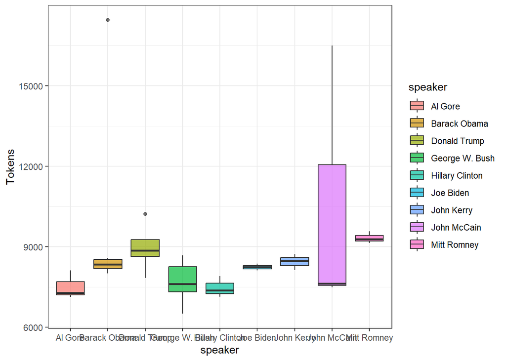

```r
summary_debate %>%
  ggplot(aes(x = speaker, y = Tokens)) +
  geom_boxplot(aes(fill = speaker), alpha = .7) +
  theme_bw()
```

## 2.3 Subsetting the Corpus

```r
corpus_obama <- corpus_subset(corpus_debate,
                              speaker == "Barack Obama")
```

# 3 Document Feature Matrix

Turn dataset into a DFM, required for e.g. Dictionary Analysis.

```r
dfm_debate <- corpus_debate %>%
  tokens(
    remove_punct = TRUE,
    remove_numbers = TRUE,
    split_hyphens = TRUE
  ) %>%
  tokens_wordstem(
    language = quanteda_options("language_stemmer"),
    verbose = quanteda_options("verbose")
  ) %>%
  tokens_remove(c("example1", "example2", stopwords("en"))) %>% #Remove specified words
  dfm()
```

## 3.1 Trim Infrequent Features

```r
dfm_debate_trim <- dfm_trim(dfm_debate,
                          min_docfreq = 2, #Has to appear in at least two texts
                          min_termfreq = 5) #Has to appear at least 5 times total

nfeat(dfm_debate_trim) #Number of unique words in the data
```

```
## [1] 2359
```

## 3.2 Inspect the DFM

```r
View(convert(dfm_debate, to = "data.frame"))
```

# 4 Analyse the DFM

## 4.1 Top 20 Features (Overall)

```r
top20_feat <- textstat_frequency(dfm_debate_trim, n = 20)
```

```r
View(top20_feat)
```

## 4.2 Top 20 Features by Speaker

```r
docvars(dfm_debate_trim)
```

```
##            speaker       date election_year type
## 1          Al Gore 2000-10-03          2000 Pres
## 2          Al Gore 2000-10-11          2000 Pres
## 3          Al Gore 2000-10-17          2000 Pres
## 4     Barack Obama 2008-09-26          2008 Pres
## 5     Barack Obama 2008-10-07          2008 Pres
## 6     Barack Obama 2008-10-15          2008 Pres
## 7     Barack Obama 2012-10-03          2012 Pres
## 8     Barack Obama 2012-10-16          2012 Pres
## 9     Barack Obama 2012-10-22          2012 Pres
## 10    Donald Trump 2016-09-26          2016 Pres
## 11    Donald Trump 2016-10-09          2016 Pres
## 12    Donald Trump 2016-10-19          2016 Pres
## 13    Donald Trump 2020-09-29          2020 Pres
## 14    Donald Trump 2020-10-22          2020 Pres
```

[output cut: 20 more lines]

```r
top20_feat_president <- textstat_frequency(dfm_debate_trim,
                                 n = 20,
                                 group = docvars(dfm_debate_trim, "speaker"))
```

```r
View(top20_feat_president)
```

# 5 Wordclouds

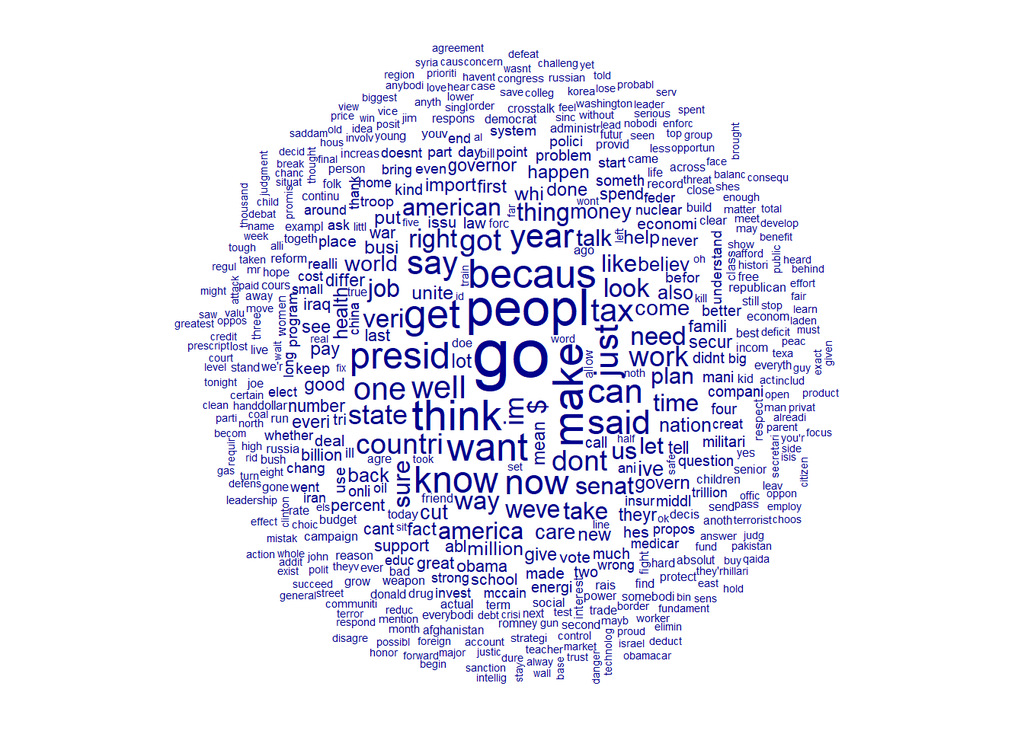

```r
textplot_wordcloud(dfm_debate_trim)
```

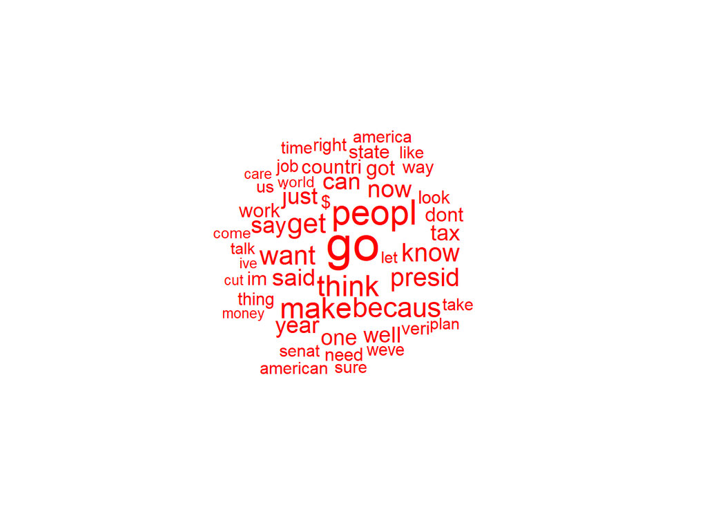

```r
textplot_wordcloud(dfm_debate_trim,
                   max_words = 50,
                   color = "red",
                   rotation = 0)
```

# 6 Keyness Analysis

Keyness analysis determines which words are used more by a predetermined group than by the other groups. E.g. which words are used more by Trump than other candidates.

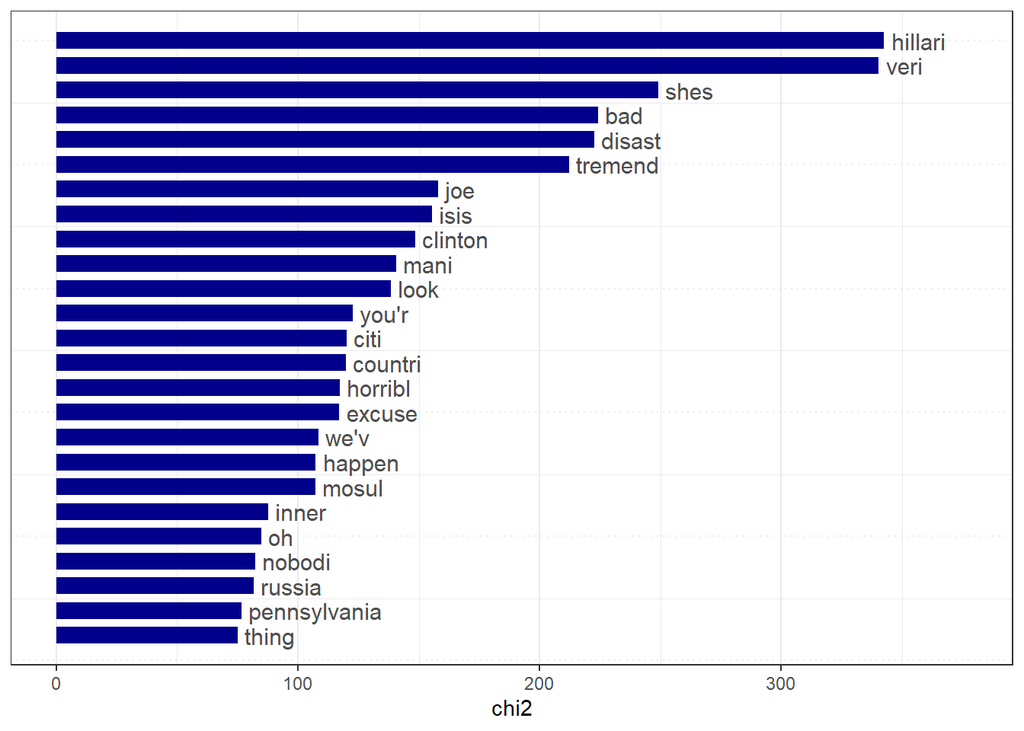

```r
#Lets group the DFM by Candidates
dfm_debate_grouped <- dfm_debate_trim %>%
  dfm_group(groups = docvars(dfm_debate_trim, "speaker"))

keyness_trump <- textstat_keyness(dfm_debate_grouped, target = "Donald Trump")

textplot_keyness(keyness_trump,
                 show_reference = FALSE,
                 n = 25)
```

# 7 Dictionary Analysis

## 7.1 Create a Custom Dictionary

Note: As we used stemming on our data, the dictionary should also contain stemmed words.

```r
wordStem("integration", language = "en")
```

```
## [1] "integr"
```

```r
list_dict <- list(
  economy = c("economi", "job", "employ", "gdp", "growth", "budget", "deficit", "debt"),
  healthcare = c("health", "medicaid", "medicar", "insur", "hospit", "doctor", "patient"),
  education = c("educ", "school", "teacher", "student", "colleg", "univers", "tuition"),
  environment = c("climat", "environ", "energi", " green", "emiss", "renew", "pollut"),
  immigration = c("immigr", "border", "citizen", "visa", "migrant", "deport"),
  foreign_policy = c("foreign", "diplomat", "diplomaci", "allianc", "nato", "trade", "tariff", "sanction"),
  social_security = c("retir", "pension", "senior", "elder", "social secur"),
  crime = c("crime", "crimin", "polic", "justic", "prison", "law")
)

topic_dict <- dictionary(list_dict)
```

## 7.2 Apply the Dictionary

```r
topic_counts <- dfm_lookup(dfm_debate_trim,
                           topic_dict)

df_topic_counts <- convert(topic_counts,
                           to = "data.frame")

df_topic_counts <- cbind(docvars(dfm_debate_trim), df_topic_counts) #Merge meta info back on the dataset
```

## 7.3 Summarise by Speaker

```r
df_topic_counts %>%
  group_by(speaker) %>%
  summarise(mean_immigration = mean(immigration),
            mean_economy = mean(economy),
            mean_environment = mean(environment),
            mean_crime = mean(crime))
```

```
## # A tibble: 9 × 5
##   speaker         mean_immigration mean_economy mean_environment mean_crime
##   <chr>                      <dbl>        <dbl>            <dbl>      <dbl>
## 1 Al Gore                     1            22.7            10         17
## 2 Barack Obama                3.83         51.8            16.5        5
## 3 Donald Trump                9.4          23.4             5.4       21
## 4 George W. Bush              8            16.2             4.5       17.2
## 5 Hillary Clinton            12.7          38.7             7.33      18.3
## 6 Joe Biden                   1.5          29              18         20
## 7 John Kerry                  5.33         33.3             2.67       9.33
## 8 John McCain                 5.67         32.3            13.3        7.33
## 9 Mitt Romney                 4.67         82              15.3        3
```

# 8 Sentiment Analysis

Sentiment Dictionary from the `quanteda.sentiment` package (Benoit, https://github.com/quanteda/quanteda.sentiment).

For this example, we will use the Lexicoder Sentiment Dictionary by Young & Soroka (2012).

```r
View(data_dictionary_LSD2015)
View(list_dict)
```

```r
debate_sent <- dfm_lookup(dfm_debate_trim,
                        data_dictionary_LSD2015)

debate_sent_df <- convert(debate_sent,
                           to = "data.frame")

debate_sent_df <- cbind(docvars(dfm_debate_trim),
                      debate_sent_df)

debate_sent_df <- debate_sent_df %>%
  mutate(sentiment_score = (positive - negative)/(positive+negative),
         perc_pos = positive/(positive+negative),
         perc_neg = negative/(positive+negative))
```

```r
View(debate_sent_df)
```

## 8.1 Visualise Sentiment Over Time

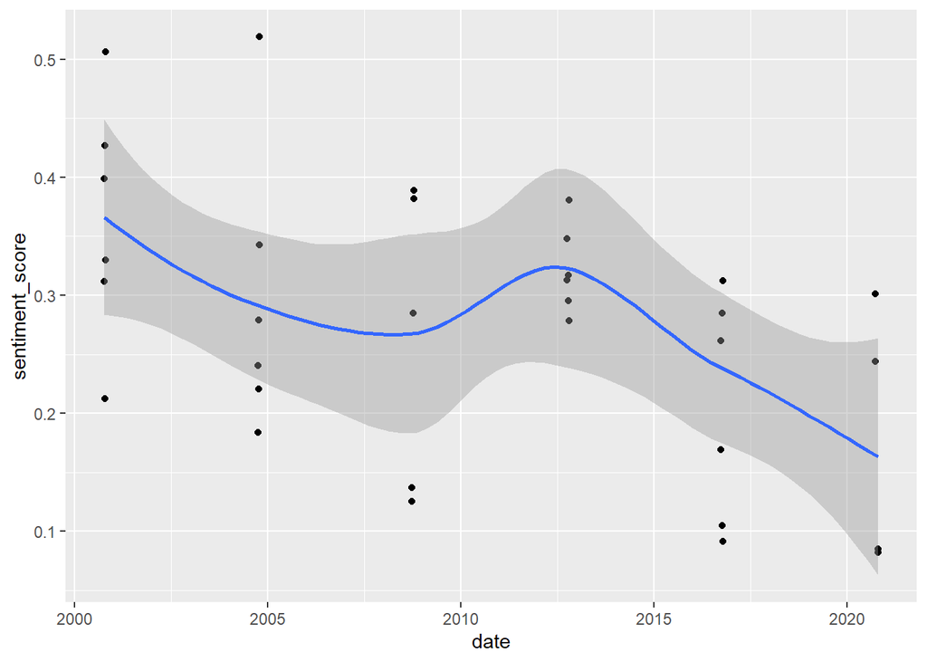

```r
ggplot(debate_sent_df, aes(x = date, y = sentiment_score)) +
  geom_point() +
  geom_smooth()
```

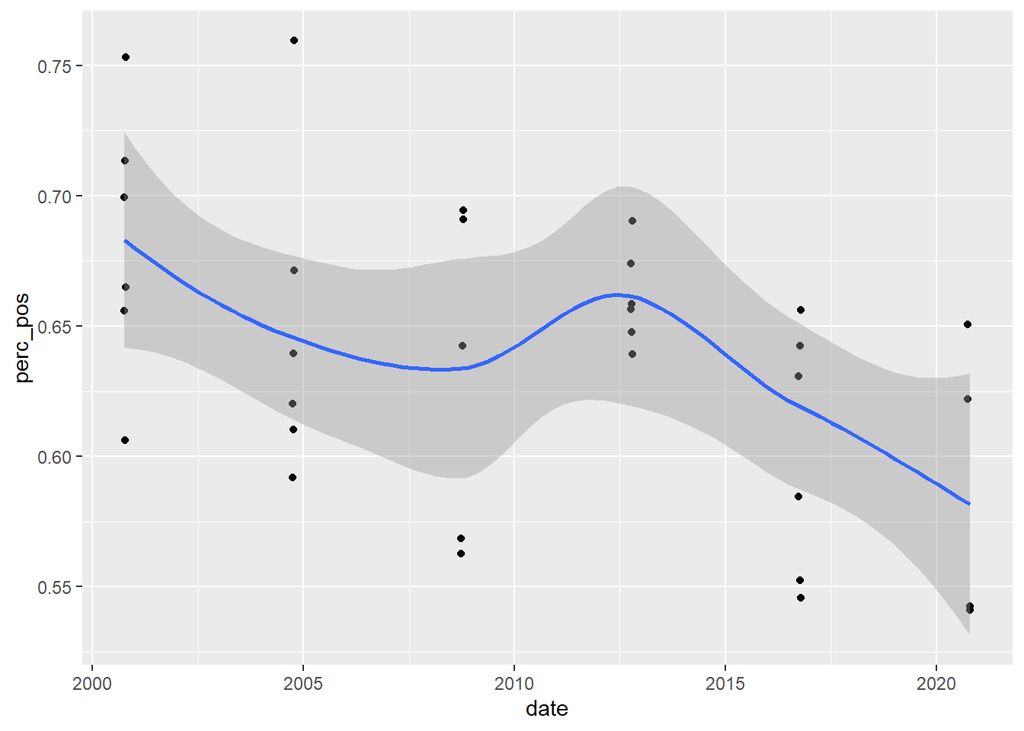

```r
ggplot(debate_sent_df, aes(x = date, y = perc_pos)) +
  geom_point() +
  geom_smooth()
```

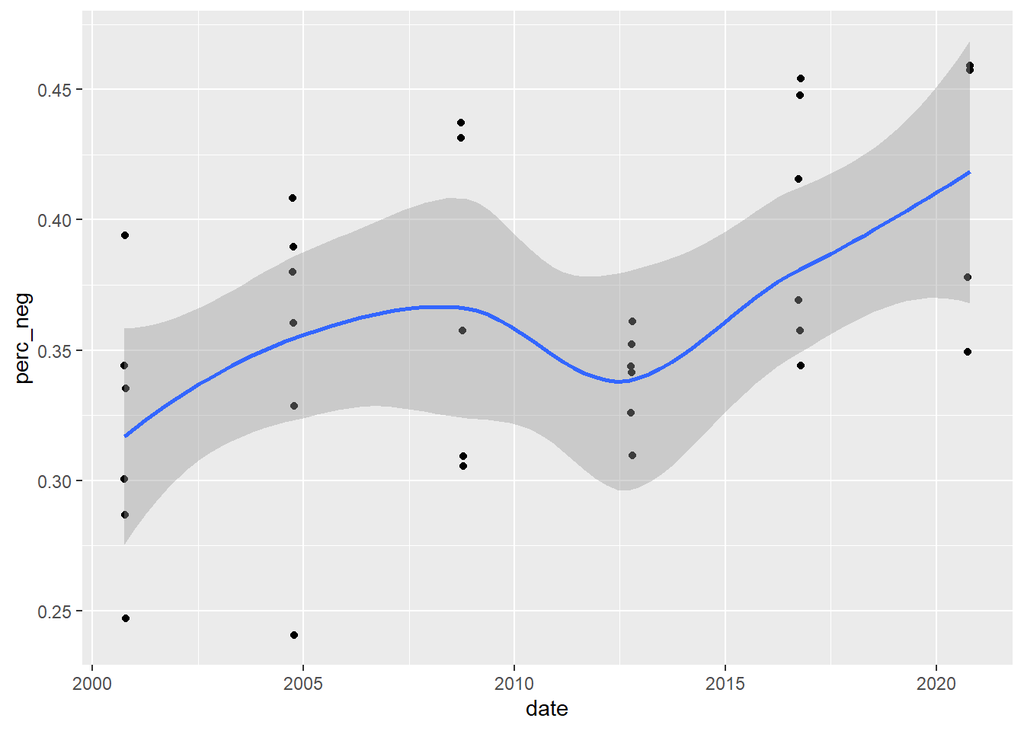

```r
ggplot(debate_sent_df, aes(x = date, y = perc_neg)) +
  geom_point() +
  geom_smooth()
```